# Peer Assessment #1

### Loading and preprocessing the data

First, we load in the data. The working directory should be set appropriately.

```r
activityData<-read.csv("activity.csv",
                        colClasses=c("numeric","character","numeric"))
```

To prepare the data to answer questions appearing later in this project, we need to convert the interval format to a numerical format for plotting.

```r
activityData$time<-sprintf("%04d",activityData$interval)
activityData$numInterval<-(as.numeric(substr(
  activityData$time,1,2))+
  as.numeric(substr(activityData$time,3,4))/60.0)*100
```

### What is the mean number of steps taken per day?

For this part of the project, we are told that we may ignore the NA values. Therefore, we prepare a smaller data set ignoring the NA values.

```r
indexNotNA<-which(!is.na(activityData$steps))
activityDataNoNA<-activityData[indexNotNA,]
```

Next, we make a histogram of the total number of steps taken per day. To do so, we first create a table which sums the number of steps over each day.

```r
totalSteps<-tapply(activityDataNoNA$steps,activityDataNoNA$date,sum)
```

We use this table to plot a histogram of the number of steps taken per day, ignoring NAs.

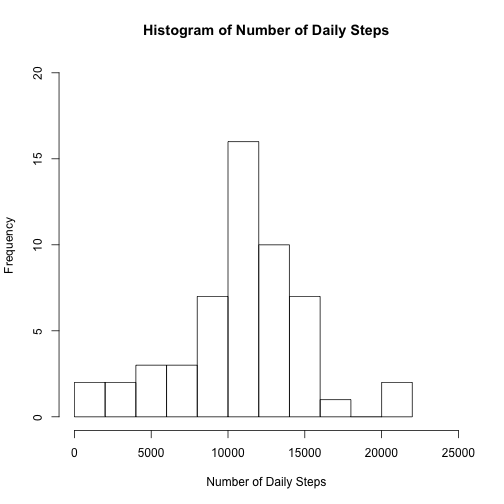

```r
par(mfrow=c(1,1))
hist(totalSteps,main="Histogram of Number of Daily Steps",
     xlim=range(0,25000),
     ylim=range(0,20),
     xlab="Number of Daily Steps",
     nclass=10)
```

Next, we compute the mean and median number of steps, ignoring NAs in the data set.

```r
#This will suppress scientific notation in our report.
options(scipen=3,digits=0)
meanSteps<-mean(totalSteps)
medianSteps<-median(totalSteps)
```

Ignoring NAs, the mean number of steps is 10766 and the median number of steps is 10765.

### What is the daily activity pattern?

```r
stepsInIntervals<-tapply(activityData$steps,
                         activityData$numInterval,sum,na.rm=TRUE)
stepsInIntervals2<-tapply(activityData$steps,
                          activityData$interval,sum,na.rm=TRUE)
```

Now, we make the time series plot.

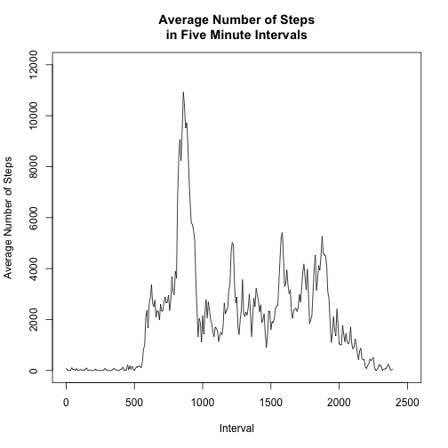

```r
plot(as.numeric(names(stepsInIntervals)),stepsInIntervals,
          type="l",
          main="Average Number of Steps\nin Five Minute Intervals",
          xlab="Interval",
          ylab="Average Number of Steps",
          xlim=range(0,2500),
          ylim=range(0,12000)
          )
```

In order to find the interval in which the maximum number of steps was taken, we make the following computation.

```r
maxStepsInInterval<-as.numeric(names(which.max(stepsInIntervals2)))
```

The maximum number of steps was taken in interval 835.

### Imputing missing values.

We count the total number of NAs below.

```r
indexNA<-which(is.na(activityData$steps))
totalNumberNAs=length(indexNA)
```

In this dataset, the total number of NAs is 2304.

We follow the following imputation rule:

**Impute a value for NA by replacing an NA for an interval with the average number of steps taken in that interval across all dates.**

The following code imputes the number of steps for NA entries using our rule.

```r
activityData$imputedSteps<-activityData$steps
intervalSteps<-tapply(activityData$steps,
       activityData$interval,mean,na.rm=TRUE)
activityData$imputedSteps[indexNA]<-
    intervalSteps[as.character(activityData$interval[indexNA])]
```

Using imputation rule, we count the number of steps.

```r
totalStepsImputed<-tapply(activityData$imputedSteps,
                          activityData$date,sum)
```

We now make a histogram using our imputation rule.

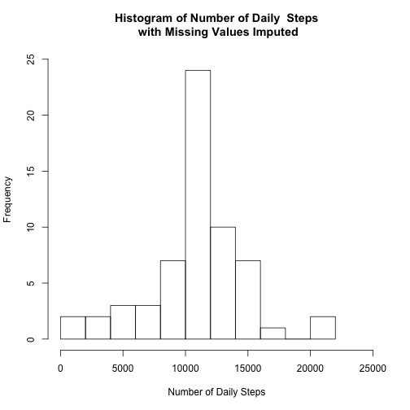

```r
hist(totalStepsImputed,main=paste("Histogram of Number of Daily",
      " Steps\n with Missing Values Imputed"),
     xlab="Number of Daily Steps",
     xlim=range(0,25000),
     ylim=range(0,25),
     nclass=10)
```

```r
meanStepsImputed<-round(mean(totalStepsImputed),0)
medianStepsImputed<-round(median(totalStepsImputed),0)
```

### Are there differences in activity patterns between weekdays and weekends?

To answer this question, we convert the day and time to a date/time format in order to identify which days are weekends and weekdays.

First, we convert the interval and date into a date/time format.

```r
activityData$time<-paste(substr(activityData$time,1,2),":",
                         substr(activityData$time,3,4),sep="")
activityData$DateTime<-as.POSIXlt(
  paste(activityData$date,activityData$time),format="%Y-%m-%d %H:%M")
activityData$time<-format(activityData$DateTime,"%H:%M")
```

Next, we determine which dates are weekdays.

```r
isWeekday<-!(weekdays(activityData$DateTime) %in% c("Sunday","Saturday"))
```

Finally, we append a marker “Weekday” or “Weekend” to the dataset.

```r
activityData$theDay<-weekdays(activityData$DateTime)
activityData$weekday[isWeekday]<-"Weekday"
activityData$weekday[!isWeekday]<-"Weekend"
isWeekday<-activityData$weekday=="Weekday"
isWeekend<-activityData$weekday=="Weekend"
```

We now create tables of weekday and weekend data.

```r
meanStepsWeekday<-tapply(activityData$imputedSteps[isWeekday],
                         activityData$numInterval[isWeekday],mean)
meanStepsWeekend<-tapply(activityData$imputedSteps[isWeekend],
                         activityData$numInterval[isWeekend],mean)
```

Next, we make a panel plot containing a time series plot of the 5-minute interval (x-axis) and the average number of steps taken, averaged across all weekday days or weekend days (y-axis).

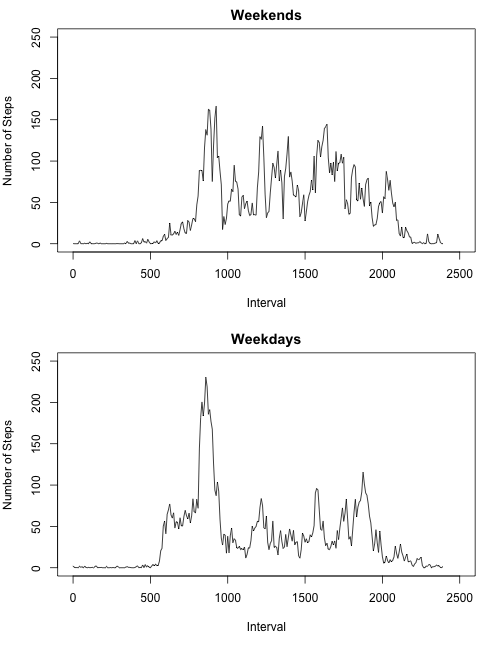

```r
par(mfrow=c(2,1),mar=c(5,4,2,2))
plot(as.numeric(names(meanStepsWeekend)),meanStepsWeekend,
     type="l",
     main="Weekends",
     xlab="Interval",
     ylab="Number of Steps",
     xlim=range(0,2500),
     ylim=range(0,250))
plot(as.numeric(names(meanStepsWeekday)),meanStepsWeekday,
     type="l",
     main="Weekdays",
     xlab="Interval",
     ylab="Number of Steps",
     xlim=range(0,2500),
     ylim=range(0,250))
```